# Module16: Applications

Dr. Wayne Stewart

2023-07-19

# Introductions

We have covered a lot of ground and it will be salutary for us to look at some applications and examples of some of the more interesting theory we have covered.

# The 32nd order statistic

The following was taken from Larsen and Marx Example 3.10.5.

The theory used relates to the $ith$ order statistic.

$$f_{Y_i^{'}(y)} =
\frac{n!}{(i-1)!(n-i)!}[F_Y(y)]^{i-1}[1-F_Y(y)]^{n-1}f_Y(y)$$
for $1\le i \le n$

## Nile river

Engineers wish to build a levee on the banks of a river in Egypt which has an annual maximum tide level $Y$ in feet governed by the pdf

$$f_Y(y) = \frac{1}{20},\;
20<y<40$$
The engineers wish to build the levee to a height $h$ so that there is only a 0.30 chance that the second worst flood in the next 33 years will overflow the embankment.

Suppose the flood tides are $Y_1, Y_2, \ldots, Y_{33}$ for the next 33 years.

We need $h$ so that $P(Y_{32}^{'} > h ) = 0.30$

The book calculates the density using the above formula and then creates the integral needed to solve the probability equation above.

However the book does not show any methodology for solving the resulting 33rd order equation.

I have done so below.

```r
# minimize the following objective function
obj <- function(x){

  abs(1-33*(x/20-1)^32 + 32*(x/20-1)^33 - 0.3)

}

optimize(f = obj, interval = c(20,40))
```

```
## $minimum
## [1] 39.33589
##
## $objective
## [1] 1.10539e-05
```

# Sum of Random Variables

## Introduction

This problem will remind you of some important techniques of distributional theory including MGFs and Bivariate random variables.

## Problem

If $Z = X + Y$ and $f(x) = e^{-x},\; x>0$, $f(y) = e^{-y},\; y>0$

### Proof a

Using MGF’s prove that $Z \sim Gamma(\alpha = 2, \beta = 1)$

#### Solution

$M_X(t) = (1-t)^{-1}$ and $M_Y(t) = (1-t)^{-1}$ since both X and Y are exponential densities.

Therefore, $M_Z(t) = M_X(t)M_Y(t) = (1-t)^{-2}$ this is the MGF of a gamma $(1-\beta t)^{-\alpha}$

$\therefore$ $Z \sim Gamma(\alpha = 2, \beta = 1)$

### Proof b

Using Bivariate distributional theory and techniques (set up integral) prove that the density of $Z$ is a $Gamma(\alpha = 2, \beta = 1)$

#### Solution

What we need to do is find the cumulative distributional function $F_Z(z)$ then differentiate to find the density.

$$f_Z(z) = \frac{dF_Z(z)}{dz}$$

Hopefully this will be the Gamma we desire!

We will start with $F_Z(z)$

$$F_Z(z) = P(Z \le z) = P(X + Y \le z) =
P(Y \le z - X)$$

$$\begin{eqnarray}F_Z(z) &=&
\int_{x = 0}^{x = z}\int_{y = 0}^{z-x}e^{-x} e^{-y} dy dx\\
&=& \int_{x = 0}^{x = z}e^{-x}\int_{y = 0}^{z-x}e^{-y} dy dx\\
&=& \int_{x = 0}^{x = z}e^{-x}\left[-e^{-y} \right]_0^{z-x} dx\\
&=&\int_{x = 0}^{x = z}e^{-x}(1-e^{x-z})dx\\
&=&\int_{x = 0}^{x = z}e^{-x} - e^{-z} dx\\
&=& \left[ -e^{-x} -xe^{-z}\right]_0^z\\
&=& -e^{-z}-ze^{-z} + 1
\end{eqnarray}$$

Now find the density:

$$\begin{eqnarray}f_Z(z) &=&
\frac{dF_Z(z)}{dz}\\
&=& \frac{d (-e^{-z}-ze^{-z} + 1)}{dz}\\
&=& e^{-z} -e^{-z} +ze^{-z}\\
&=& ze^{-z}\\
f(y)&=& \frac{y^{\alpha-1}e^{-y/\beta}}{\beta^\alpha
\Gamma(\alpha)},\; Gamma\; Density\; \mu = \alpha\beta,\; \sigma^2 =
\alpha\beta^2
\end{eqnarray}$$

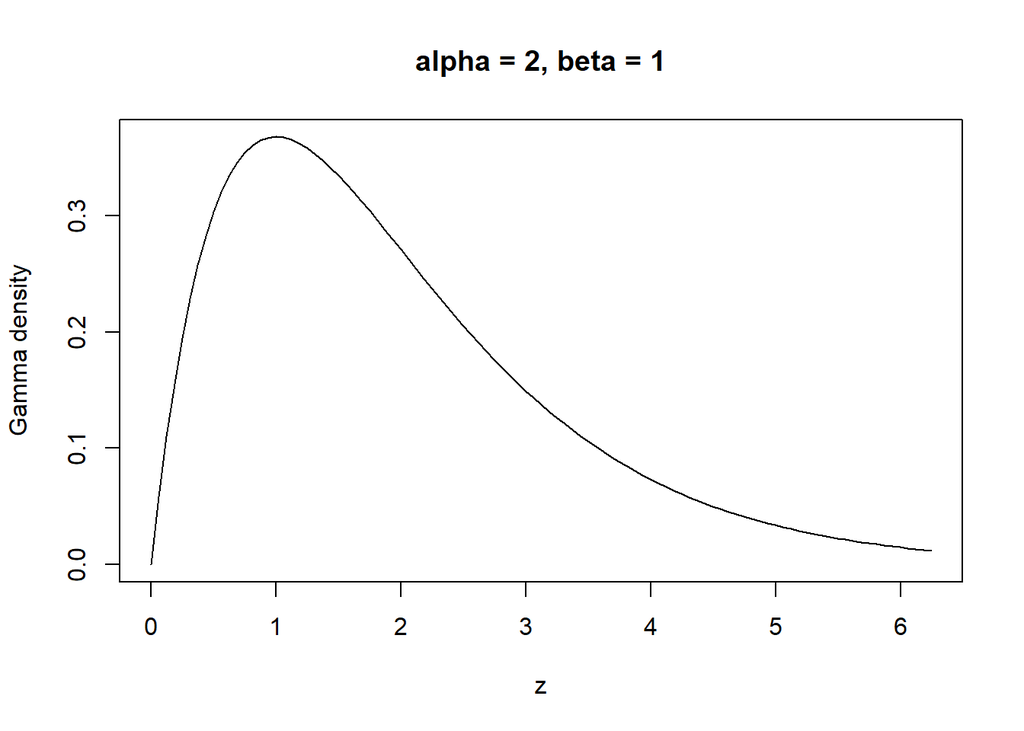

```r
dg <- function(x) {
  x*exp(-x)
}

curve(expr = dg,
      xlim = c(0, 2 +3*sqrt(2)), # 0,mu + 3 sigma
      main = "alpha = 2, beta = 1",
      ylab = "Gamma density",
      xlab = "z")
```

So $Z\sim Gamma(\alpha = 2, \beta = 1)$. Note that:
$$f(z) =
\frac{z^{2-1}e^{-z/1}}{1^2\Gamma(2)} = ze^{-z}$$